# assignmentMarkdown.Rmd

Ahmed Ameen

11/21/2020

## R Markdown

This is an R Markdown document.It contains all steps that I did with dataset

1- First loading data

```r
library(dplyr)
```

```r
library(ggplot2)
 myDataSet <- read.csv('data/activity.csv')
```

2- Converting data variable from character to data

```r
  myData <- transform(myDataSet , date = as.Date(date))
```

3- Histogram of the total number of steps taken each day

```r
daysWithTotalSteps <- summarize(group_by(myData,date),stepsTotal = sum(steps,na.rm =  TRUE))
```

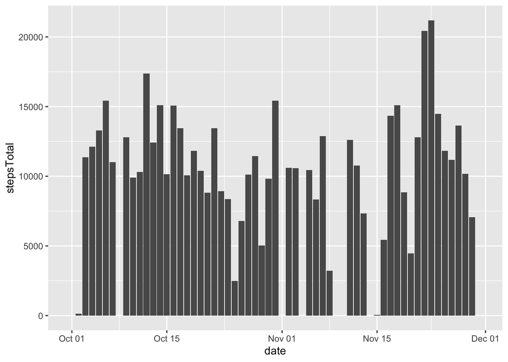

```r
ggplot(daysWithTotalSteps, aes(date, stepsTotal)) + geom_bar(stat="identity")
```

4-Mean and median number of steps taken each day

```r
daysWithMainAndMEdianSteps <- summarize(group_by(myData,date),stepsMean = mean(steps,na.rm =  TRUE),stepsMedian = median(steps,na.rm =  TRUE))
daysWithMainAndMEdianSteps
```

```
## # A tibble: 61 x 3
##    date       stepsMean stepsMedian
##    <date>         <dbl>       <dbl>
##  1 2012-10-01   NaN              NA
##  2 2012-10-02     0.438           0
##  3 2012-10-03    39.4             0
##  4 2012-10-04    42.1             0
##  5 2012-10-05    46.2             0
##  6 2012-10-06    53.5             0
##  7 2012-10-07    38.2             0
##  8 2012-10-08   NaN              NA
##  9 2012-10-09    44.5             0
## 10 2012-10-10    34.4             0
## # … with 51 more rows
```

5- Time series plot of the average number of steps taken

```r
intervalsWithMainSteps <- summarize(group_by(myData,interval),stepsMean = mean(steps,na.rm =  TRUE))
```

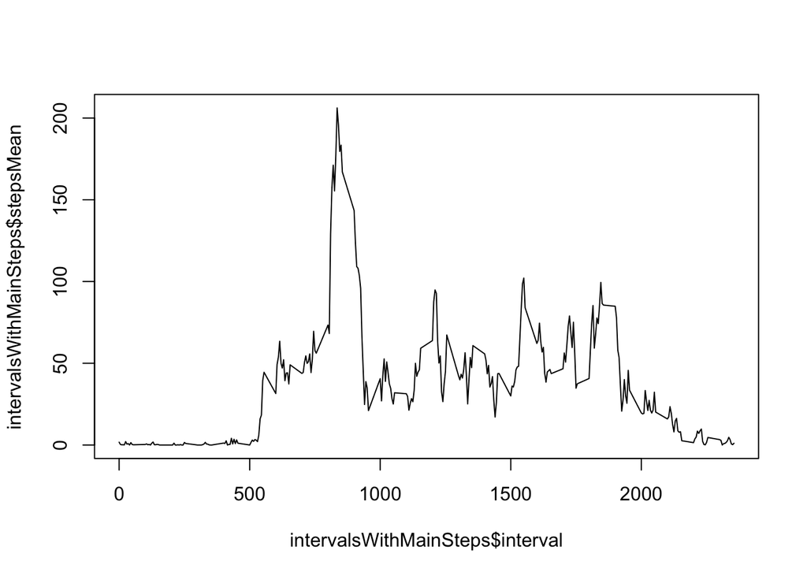

```r
plot( intervalsWithMainSteps$stepsMean ~ intervalsWithMainSteps$interval,type="l")
```

7-A Code to describe and show a strategy for imputing missing data

```r
numberOfNaSteps = sum(is.na(myData$steps))
propOfNaSteps = numberOfNaSteps / length(myData$steps)
```

The total number of missing values in the dataset is 2304 of 17568 and its prop is 0.1311475

7-B,7-C

I fill the missing values with the mean for that 5-minute interval.

```r
#loop through all rows
  for ( i in 1:nrow(myData)) {
    #check if steps variable is na
    if(is.na(myData[i,][1])) {

      #fill the steps variable with its corresponding mean interval
       myData[i,][1] = intervalsWithMainSteps$stepsMean[which(intervalsWithMainSteps$interval == myData[i,][3]$interval)]
    }
  }
```

7-D Make a histogram of the total number of steps taken each day

```r
daysWithTotalStepsOfNewDataSet <- summarize(group_by(myData,date),stepsTotal = sum(steps))
```

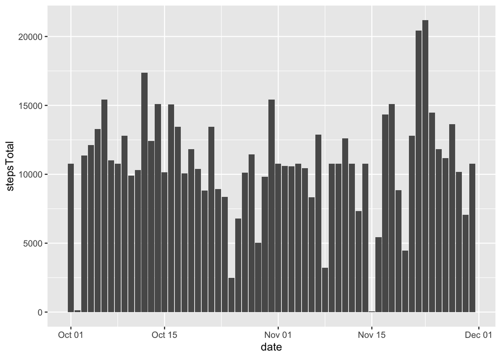

```r
ggplot(daysWithTotalStepsOfNewDataSet, aes(date, stepsTotal)) + geom_bar(stat="identity")
```

```r
daysWithMainAndMEdianStepsOfNewDataSet <- summarize(group_by(myData,date),stepsMean = mean(steps),stepsMedian = median(steps))
daysWithMainAndMEdianStepsOfNewDataSet
```

```
## # A tibble: 61 x 3
##    date       stepsMean stepsMedian
##    <date>         <dbl>       <dbl>
##  1 2012-10-01    37.4          34.1
##  2 2012-10-02     0.438         0
##  3 2012-10-03    39.4           0
##  4 2012-10-04    42.1           0
##  5 2012-10-05    46.2           0
##  6 2012-10-06    53.5           0
##  7 2012-10-07    38.2           0
##  8 2012-10-08    37.4          34.1
##  9 2012-10-09    44.5           0
## 10 2012-10-10    34.4           0
## # … with 51 more rows
```

7-F

8-A

Creating a new weedays column that contains weekday, weekend values.

```r
myData <- transform(myData , weekdays = ifelse(weekdays(date) %in% c("Saturday","Sunday"),"weekend","weekday"))
myData$weekdays <-as.factor(myData$weekdays)
```

8-B

Make a panel plot containing a time series plot (i.e. type = “l”) of the 5-minute interval (x-axis) and the average number of steps taken, averaged across all weekday days or weekend days (y-axis)

```r
intervalsWithMainSteps <- summarize(group_by(myData,weekdays,interval),stepsMean = mean(steps))
```

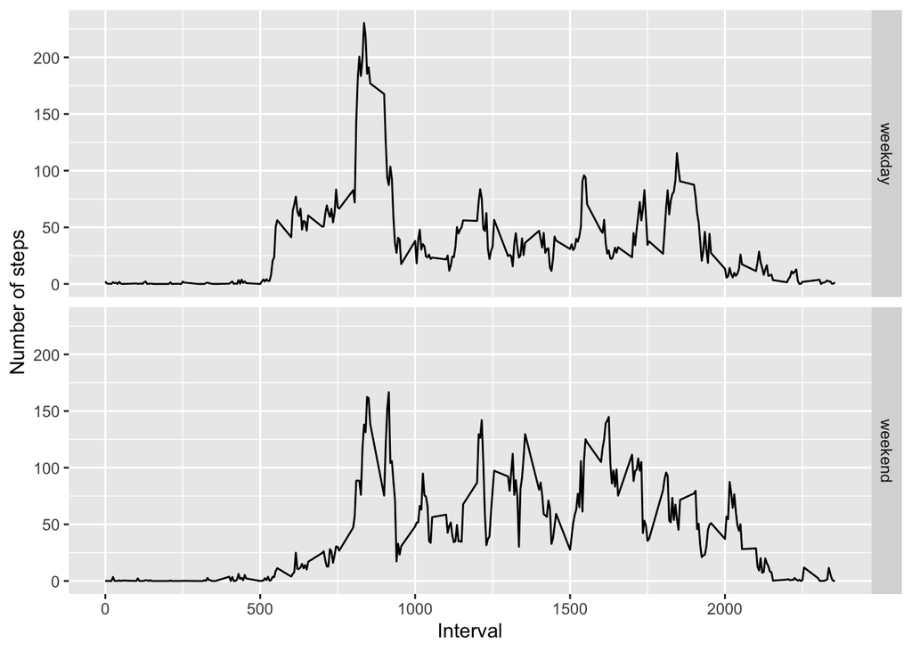

```r
g<- ggplot(intervalsWithMainSteps, aes( intervalsWithMainSteps$interval, intervalsWithMainSteps$stepsMean))
g + geom_line()  + facet_grid(weekdays ~ .)  +   xlab("Interval") + ylab("Number of steps")
```